# Report

Camila and Jessica

2024-03-26

# **INTRODUCTION**

In this analysis, we will investigate the association between body mass index (BMI) and the prevalence of hypertension among participants in the Framingham Heart Study. Obesity, often determined by BMI, is recognized as one of the principal risk factors for hypertension. Numerous studies have demonstrated that the prevalence of hypertension increases with rising BMI, therefore, understanding the relationship between BMI and hypertension prevalence is important for identifying individuals at risk, developing effective prevention as well as management strategies for hypertension.

# **METHODS**

For this study we want to understand the association between BMI and the prevalence of hypertension on the Framingham Heart Study data set.

## Cleaning the Data

- The Framingham data set we used was pre-processed but still included missing values (NA’s) and because we do not want these NA’s to affect our results we decided remove the NA’s and this reduced the number of our observations. Additionally, we changed the column name of our dependent variable from ‘PrevalentHYP’ to ‘pHyp’ for clarity.

## Generating and Testing Hypothesis

- **Null Hypothesis**: There is no association between BMI and the prevalence of hypertension among the studied population.

  **Alternative Hypothesis**: There is an association between BMI and the prevalence of hypertension among the studied population.

To test these hypotheses, we visualized the associations between BMI and hypertension using boxplots and computed the BMI median for hypertensive and non-hypertensive groups. Furthermore, we employed a logistic regression model and a t-test to assess the statistical significance of our findings.

# **RESULTS**

## Boxplot and median

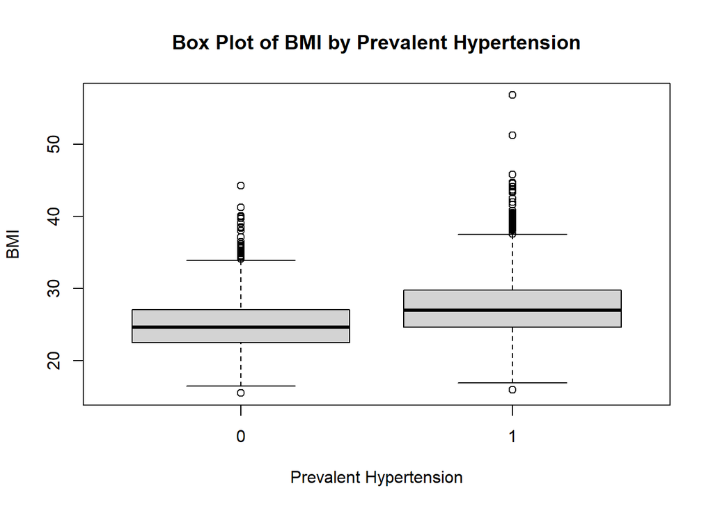

```
## [1] 27
```

```
## [1] 24.67
```

The boxplot comparison shows a median BMI of 27 for the Hypertensive group and 24.67 for the Non-Hypertensive group. This suggests a potential association between higher BMI and hypertension.

## Logistic regression model and t-test

```
##
## Call:  glm(formula = pHyp ~ BMI, family = binomial, data = cleaned_data)
##
## Coefficients:
## (Intercept)          BMI
##     -5.2594       0.1707
##
## Degrees of Freedom: 3657 Total (i.e. Null);  3656 Residual
## Null Deviance:       4539
## Residual Deviance: 4200  AIC: 4204
```

```
##
##  Welch Two Sample t-test
##
## data:  pHyp_bmi and nopHyp_bmi
## t = 17.442, df = 1772.9, p-value < 2.2e-16
## alternative hypothesis: true difference in means is not equal to 0
## 95 percent confidence interval:
##  2.359899 2.957859
## sample estimates:
## mean of x mean of y
##  27.61305  24.95417
```